# Practical Machine Learning

Yadder Aceituno

August 19, 2019

## Libraries

```r
library(caret)
library(corrplot)
library(rattle)
```

## Overview

Using devices such as Jawbone Up, Nike FuelBand, and Fitbit it is now possible to collect a large amount of data about personal activity relatively inexpensively. These type of devices are part of the quantified self movement. A group of enthusiasts who take measurements about themselves regularly to improve their health, to find patterns in their behavior, or because they are tech geeks. One thing that people regularly do is quantify how much of a particular activity they do, but they rarely quantify how well they do it. In this project, the goal will be to use data from accelerometers on the belt, forearm, arm, and dumbell of 6 participants. They were asked to perform barbell lifts correctly and incorrectly in 5 different ways.

The goal is to predict the manner they did the different excercises. There is a variable called classe which stores 5 different classes:

- Class A - exactly according to the specification.
- Class B - throwing the elbows to the front.
- Class C - lifting the dumbbell only halfway.
- Class D - lowering the dumbbell only halfway.
- Class E - throwing the hips to the front.

We’ll build different prediction models to compare them and decide which model is the best to predict the variable classe.

## Getting Data

The data comes from this source: http://web.archive.org/web/20161224072740/http:/groupware.les.inf.puc-rio.br/har.

Getting the testing and training data

```r
training <- read.csv("pml-training.csv")
testing <- read.csv("pml-testing.csv")

# Checking dimensions
dim(training)
```

```
## [1] 19622   160
```

```r
dim(testing)
```

```
## [1]  20 160
```

We can see that training data frame has 19622 rows. We will use this data frame to build our models. We also can see that testing data frame has 20 rows. We will use this data frame to check each model builded.

## Partition Data

```r
# Setting seed to reproduce the results
set.seed(12345)

inTrain <- createDataPartition(training$classe, p = 0.7, list = FALSE)

myTraining <- training[inTrain,]
myTesting <- training[-inTrain,]


# Checking dimensions
dim(myTraining)
```

```
## [1] 13737   160
```

```r
dim(myTesting)
```

```
## [1] 5885  160
```

## Cleaning Training Data

### Identifying Covariates

First we need to take a first look to identify those variables which will help to build our model. Those are:

```r
# Identifying covariates
covariates <- c("classe", "roll_belt","pitch_belt", "yaw_belt", "total_accel_belt", "gyros_belt_x", "gyros_belt_y", "gyros_belt_z",
"accel_belt_x", "accel_belt_y", "accel_belt_z", "magnet_belt_x", "magnet_belt_y", "magnet_belt_z", "roll_arm", "pitch_arm", "yaw_arm",
"total_accel_arm", "gyros_arm_x", "gyros_arm_y", "gyros_arm_z", "accel_arm_x", "accel_arm_y", "accel_arm_z", "magnet_arm_x", "magnet_arm_y",
"magnet_arm_z", "roll_dumbbell", "pitch_dumbbell", "yaw_dumbbell", "gyros_dumbbell_x", "gyros_dumbbell_y", "gyros_dumbbell_z", "accel_dumbbell_x",
"accel_dumbbell_y", "accel_dumbbell_z", "magnet_dumbbell_x", "magnet_dumbbell_y", "magnet_dumbbell_z", "roll_forearm", "pitch_forearm",
"yaw_forearm", "total_accel_forearm", "gyros_forearm_x", "gyros_forearm_y", "gyros_forearm_z", "accel_forearm_x", "accel_forearm_y",
"accel_forearm_z","magnet_forearm_x", "magnet_forearm_y", "magnet_forearm_z")

# Reducing covariates
myTraining <- myTraining[, covariates]
myTesting <- myTesting[, covariates]

testing <- testing[, covariates[2:length(covariates)]]
```

### Removing Zero Covariates

We need to identify covariates that will not help to build our model. Using nearZeroVar function we can identify those variables which have low variabilty.

```r
nzv <- nearZeroVar(myTraining, saveMetrics = TRUE)

# Looking covariates with near zero variabilty
nzv[nzv$nzv == TRUE,]
```

```
## [1] freqRatio     percentUnique zeroVar       nzv
## <0 rows> (or 0-length row.names)
```

We can see that all variables have variabity. Using nearZeroVar function we didn’t remove any variable.

## Correlation Analysis

We need to identify if the dataset has some correlated variables before procede to build the models.

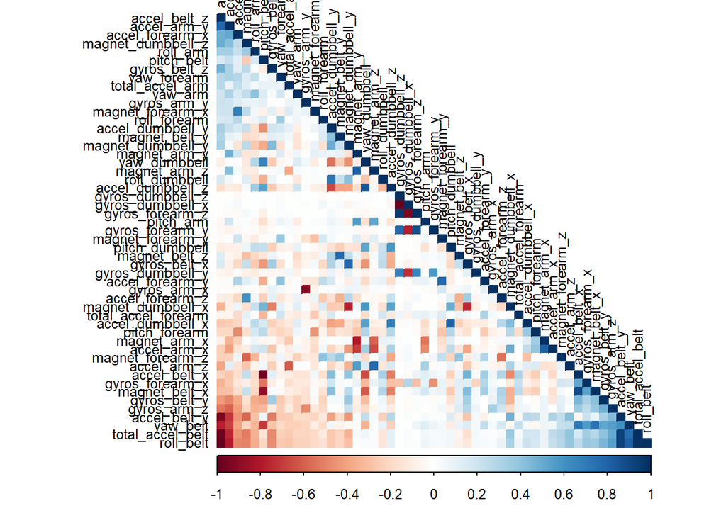

```r
corMatrix <-cor(myTraining[,-1])

corrplot(corMatrix, order = "FPC", method = "color", type = "lower",
         tl.cex = 0.8, tl.col = rgb(0, 0, 0))
```

## Building Models

### Using Trees

Let’s create our first model using trees. Then we’ll make a cross validatios to compare results.

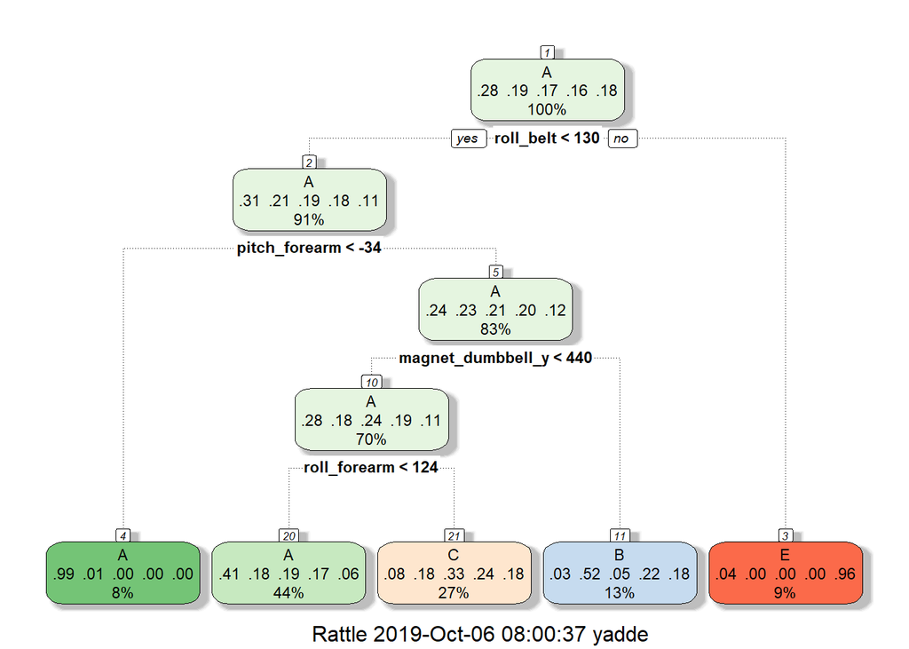

```r
model1 <- train(classe ~ ., method = "rpart", data = myTraining)

fancyRpartPlot(model1$finalModel)
```

Lookig the previous rpart tree we can see how the builded model predicts classe variable. Let’s make a prediction with the model using myTesting.

```r
predict1 <- predict(model1, newdata = myTesting)

confusionMatrix(predict1, myTesting$classe)
```

```
## Confusion Matrix and Statistics
##
##           Reference
## Prediction    A    B    C    D    E
##          A 1494  470  467  438  141
##          B   21  380   29  184  147
##          C  128  289  530  342  277
##          D    0    0    0    0    0
##          E   31    0    0    0  517
##
## Overall Statistics
##
##                Accuracy : 0.4963
##                  95% CI : (0.4835, 0.5092)
##     No Information Rate : 0.2845
##     P-Value [Acc > NIR] : < 2.2e-16
##
##                   Kappa : 0.3425
##
##  Mcnemar's Test P-Value : NA
##
## Statistics by Class:
##
##                      Class: A Class: B Class: C Class: D Class: E
## Sensitivity            0.8925  0.33363  0.51657   0.0000  0.47782
## Specificity            0.6400  0.91972  0.78679   1.0000  0.99355
## Pos Pred Value         0.4963  0.49934  0.33844      NaN  0.94343
## Neg Pred Value         0.9374  0.85187  0.88516   0.8362  0.89414
## Prevalence             0.2845  0.19354  0.17434   0.1638  0.18386
## Detection Rate         0.2539  0.06457  0.09006   0.0000  0.08785
## Detection Prevalence   0.5115  0.12931  0.26610   0.0000  0.09312
## Balanced Accuracy      0.7662  0.62667  0.65168   0.5000  0.73568
```

### Random Forest

Now let’s build a model using the random forest method and let’s look the results of the model.

```r
# Building the model
model2 <- train(classe ~ ., method = "rf", data = myTraining)

predict2 <- predict(model2, newdata = myTesting)
confusionMatrix(predict2, myTesting$classe)
```

```
## Confusion Matrix and Statistics
##
##           Reference
## Prediction    A    B    C    D    E
##          A 1673   10    0    0    0
##          B    1 1124   15    0    0
##          C    0    5 1007   22    0
##          D    0    0    4  942    4
##          E    0    0    0    0 1078
##
## Overall Statistics
##
##                Accuracy : 0.9896
##                  95% CI : (0.9867, 0.9921)
##     No Information Rate : 0.2845
##     P-Value [Acc > NIR] : < 2.2e-16
##
##                   Kappa : 0.9869
##
##  Mcnemar's Test P-Value : NA
##
## Statistics by Class:
##
##                      Class: A Class: B Class: C Class: D Class: E
## Sensitivity            0.9994   0.9868   0.9815   0.9772   0.9963
## Specificity            0.9976   0.9966   0.9944   0.9984   1.0000
## Pos Pred Value         0.9941   0.9860   0.9739   0.9916   1.0000
## Neg Pred Value         0.9998   0.9968   0.9961   0.9955   0.9992
## Prevalence             0.2845   0.1935   0.1743   0.1638   0.1839
## Detection Rate         0.2843   0.1910   0.1711   0.1601   0.1832
## Detection Prevalence   0.2860   0.1937   0.1757   0.1614   0.1832
## Balanced Accuracy      0.9985   0.9917   0.9880   0.9878   0.9982
```

Using random forest we can see that we get a good prediction. The model has 0.98 value of accuracy which is a great value.

### Boosting

Now we’ll use boosting with trees to get a new model. Let’s use gbm which can help us to build our boosted model using trees.

```r
# Building the model
model3 <- train(classe ~ ., method = "gbm", data = myTraining, verbose = FALSE)

predict3 <- predict(model3, newdata = myTesting)
confusionMatrix(predict3, myTesting$classe)
```

```
## Confusion Matrix and Statistics
##
##           Reference
## Prediction    A    B    C    D    E
##          A 1645   37    0    2    1
##          B   22 1071   38    2   12
##          C    2   27  972   34    6
##          D    5    4   14  923   21
##          E    0    0    2    3 1042
##
## Overall Statistics
##
##                Accuracy : 0.9606
##                  95% CI : (0.9553, 0.9654)
##     No Information Rate : 0.2845
##     P-Value [Acc > NIR] : < 2.2e-16
##
##                   Kappa : 0.9501
##
##  Mcnemar's Test P-Value : 1.183e-06
##
## Statistics by Class:
##
##                      Class: A Class: B Class: C Class: D Class: E
## Sensitivity            0.9827   0.9403   0.9474   0.9575   0.9630
## Specificity            0.9905   0.9844   0.9858   0.9911   0.9990
## Pos Pred Value         0.9763   0.9354   0.9337   0.9545   0.9952
## Neg Pred Value         0.9931   0.9857   0.9889   0.9917   0.9917
## Prevalence             0.2845   0.1935   0.1743   0.1638   0.1839
## Detection Rate         0.2795   0.1820   0.1652   0.1568   0.1771
## Detection Prevalence   0.2863   0.1946   0.1769   0.1643   0.1779
## Balanced Accuracy      0.9866   0.9624   0.9666   0.9743   0.9810
```

### Naive Bayes

Now we’ll build a model using naive bayes method. Let’s look the result:

```r
# Building the model
model4 <- train(classe ~ ., method = "nb", data = myTraining, verbose = FALSE)

predict4 <- predict(model4, newdata = myTesting)
confusionMatrix(predict4, myTesting$classe)
```

```
## Confusion Matrix and Statistics
##
##           Reference
## Prediction    A    B    C    D    E
##          A 1504  247  256  202   67
##          B   37  744   75    4   89
##          C   40   80  648  109   39
##          D   83   57   45  603   40
##          E   10   11    2   46  847
##
## Overall Statistics
##
##                Accuracy : 0.7385
##                  95% CI : (0.7271, 0.7497)
##     No Information Rate : 0.2845
##     P-Value [Acc > NIR] : < 2.2e-16
##
##                   Kappa : 0.6647
##
##  Mcnemar's Test P-Value : < 2.2e-16
##
## Statistics by Class:
##
##                      Class: A Class: B Class: C Class: D Class: E
## Sensitivity            0.8984   0.6532   0.6316   0.6255   0.7828
## Specificity            0.8167   0.9568   0.9448   0.9543   0.9856
## Pos Pred Value         0.6608   0.7840   0.7074   0.7283   0.9247
## Neg Pred Value         0.9529   0.9200   0.9239   0.9286   0.9527
## Prevalence             0.2845   0.1935   0.1743   0.1638   0.1839
## Detection Rate         0.2556   0.1264   0.1101   0.1025   0.1439
## Detection Prevalence   0.3867   0.1613   0.1556   0.1407   0.1556
## Balanced Accuracy      0.8576   0.8050   0.7882   0.7899   0.8842
```

We can see that the accuracy for the previous model is 0.74.

## Prediction For Testing Data

Now that we already built different models, we have to decide which model to use. Validating the different results from the different models we can look that random forest give us a great prediction. We’ll use that model to predict the classe variable in testing data set.

```r
prediction <- predict(model2, newdata = testing)

prediction
```

```
##  [1] B A B A A E D B A A B C B A E E A B B B
## Levels: A B C D E
```

We can see the final prediction for testing data with 99% of accuracy using random forest as method to build the prediction model.